# Extra Exercise 16.5

Kata Süle

7th February 2021

## Aim

This exercise is aimed at predicting hotel prices with a random forest model using the hotels-europe dataset.

## Sample design and feature selection

All prices were collected for a weekend in April 2018 in 31 European countries.

I filtered variables that only had one outcome as well as Tripadvisor ratings, their counts and stars because more than a 1000 of them was missing. Furthermore, I filtered the alternative distance variable because I think distance from the city center was a more important feature. I created factor variables for all the countries and cities, the offer categories, the accommodation types and the scarce room variable. As for the offer categories I grouped the ‘75%+ offer’ and ‘50%-75% offer’ categories into one because they did have much less observations separately compared to the other categories. As for the accommodation type I only kept those categories which had more than 200 observations. I only kept observations whose price was below 1500 euros per night.

The rating and rating count variables had missing values. I used the mean to impute the rating variable and the median to impute the rating count and added flags to mark these imputed values.

## Modeling

I created a training and a holdout sample which contained 70% and 30% of the observations respectively. I used 5-fold cross-validation to estimate random forest models with price as the target variable. I used 10 predictors for the estimation.

The table below shows the cross-validated RMSE values for all the random forest models. The best model chose 5 variables randomly at each split for each tree and had 15 observations in the final nodes. Based on the cross-validated RMSE the best model makes an error of 97.76 euros in general. This model had an RMSE of 88.35 for the holdout sample. This means that the model makes an error of 88.35 euros in general.

Performance of random forest models

| Num. vars | Min. node size | CV RMSE |
| --- | --- | --- |
| 2 | 5 | 106.16 |
| 2 | 10 | 106.14 |
| 2 | 15 | 106.13 |
| 3 | 5 | 101.79 |
| 3 | 10 | 101.87 |
| 3 | 15 | 101.83 |
| 5 | 5 | 97.96 |
| 5 | 10 | 97.80 |
| 5 | 15 | 97.76 |

## Variable importance plots

I created two variable importance plots. The first one shows only the top 10 cities as separate variables, while the second one shows the cities as a group.

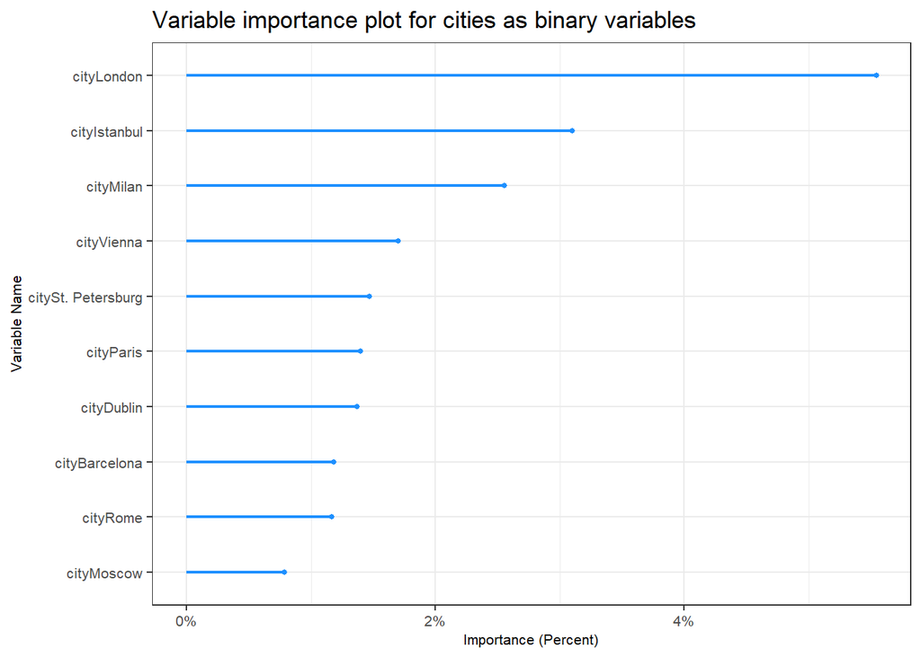

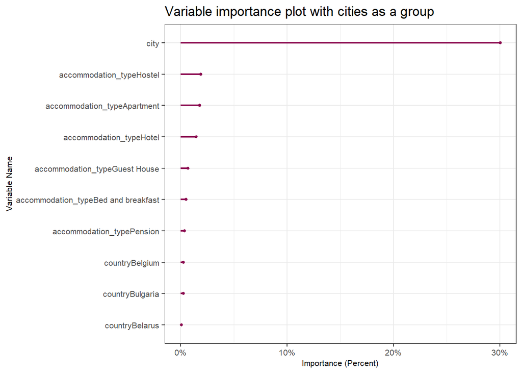